# mcpgt

```python
from IPython.display import Image
import numpy as np
from matplotlib import pyplot as plt
%matplotlib inline
from adsy.display import extended_styles
from collections import defaultdict
```

*Without having to look at the results at all, the finding is that when we do the "$2\times2$" set of PGT experiments with Monte Carlo instead of exhaustive search, we get very similar distributions for expected utility. In other words, Monte Carlo works*.

## Perfect Information

```python
extended_styles()
```

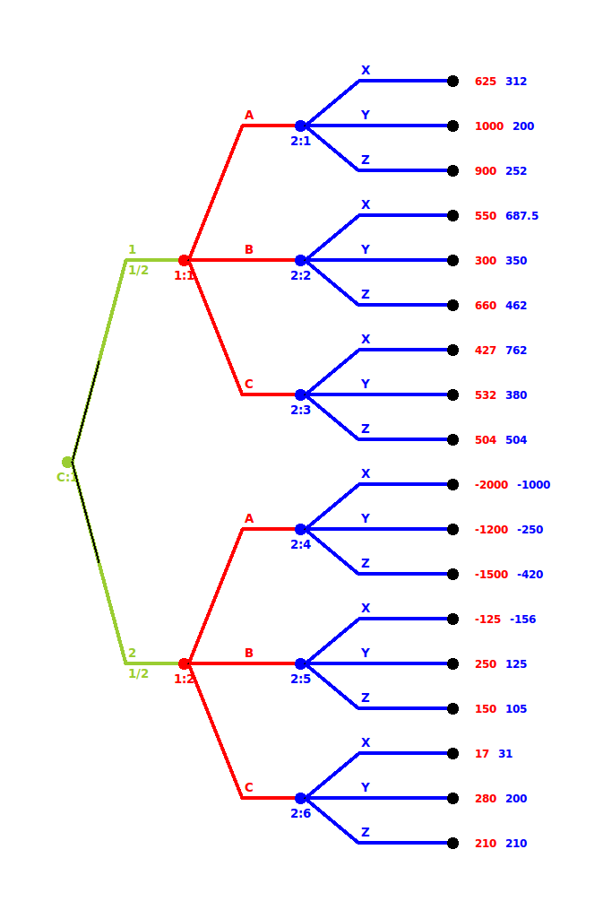

```python
Image('perfectinfo.png')
```

```python
import itertools
perfect_strat_1 = list(itertools.product(["A", "B", "C"], ["A", "B", "C"]))
perfect_strat_2 = list(itertools.product(["X", "Y", "Z"], ["X", "Y", "Z"], ["X", "Y", "Z"],
                                         ["X", "Y", "Z"], ["X", "Y", "Z"], ["X", "Y", "Z"]))
perfect_stratprofiles = list(itertools.product(perfect_strat_1, perfect_strat_2))
mapdict = {"A": 0, "B":1, "C":2}
utils = {"HAX": (625, 312),
         "HAY": (1000, 200),
         "HAZ": (900, 252),
         "HBX": (550, 687.5),
         "HBY": (300, 350),
         "HBZ": (660, 462),
         "HCX": (427, 762),
         "HCY": (532, 380),
         "HCZ": (504, 504),
         "LAX": (-2000, -1000),
         "LAY": (-1200, -250),
         "LAZ": (-1500, -420),
         "LBX": (-125, -156),
         "LBY": (250, 125),
         "LBZ": (150, 105),
         "LCX": (17, 31),
         "LCY": (280, 200),
         "LCZ": (210, 210)
}
```

```python
np.random.choice?
```

```python
def EU_with_trembles_perfect_info(p1strat, p2strat, utils=utils, p1top2map=mapdict, p1trembleprob=.2,
                     p2trembleprob=.2, p1tremblestrats=perfect_strat_1, p2tremblestrats=perfect_strat_2):
    """
    Computes the expected utility of player 1 and player 2.

    Nature node is hard coded to p=.5 for both outcomes.

    Setting trembleprobs to 0 gives standard intelligence
    """
    highukey = "H"+p1strat[0]+p2strat[mapdict[p1strat[0]]]
    lowukey =  "L"+p1strat[1]+p2strat[3 + mapdict[p1strat[1]]]
    p1eunotremb = (1-p2trembleprob) * (.5 * utils[highukey][0] + .5 * utils[lowukey][0])
    p2eunotremb = (1-p1trembleprob) * (.5 * utils[highukey][1] + .5 * utils[lowukey][1])
    if p1trembleprob + p2trembleprob ==0:
        return p1eunotremb, p2eunotremb
    ### Get the utility that is associated with p2 trembling
    p1epovern = p1trembleprob/float(len(p1tremblestrats) - 1)
    p2epovern = p2trembleprob/float(len(p2tremblestrats) - 1)
    p1tremblingeu = 0 # Utility of p1 when p2 trembles
    p2tremblingeu = 0 # Utility of p2 when p1 trembles
    for s in p2tremblestrats:
        if s != p2strat:
            highukey = "H"+p1strat[0]+s[mapdict[p1strat[0]]]
            lowukey =  "L"+p1strat[1]+s[3 + mapdict[p1strat[1]]]
            p1tremblingeu += p2epovern * (.5 * utils[highukey][0] + .5 * utils[lowukey][0])
    for s in p1tremblestrats:
        if s != p1strat:
            highukey = "H"+s[0]+p2strat[mapdict[s[0]]]
            lowukey =  "L"+s[1]+p2strat[3 + mapdict[s[1]]]
            p2tremblingeu += p1epovern * (.5 * utils[highukey][1] + .5 * utils[lowukey][1])
    return p1eunotremb + p1tremblingeu, p2eunotremb + p2tremblingeu

def get_trembling_intelligence_perfect_info_mc(profile, p1trembleprob=.2, p2trembleprob=.2, numalt=30):
    """
    Get's the trembling intelligence of a profile under trembling
    """
    p1strat = profile[0]
    p2strat = profile[1]
    util = EU_with_trembles_perfect_info(p1strat, p2strat, p1trembleprob=p1trembleprob, p2trembleprob=p2trembleprob)
    #print util
    p1_numalt = float(len(perfect_strat_1))
    p2_numalt = float(len(perfect_strat_2))
    num_no_betterp1 = 0
    num_no_betterp2 = 0
    for ix in np.random.choice(range(len(perfect_strat_1)), size=numalt):
        s = perfect_strat_1[ix]
        if EU_with_trembles_perfect_info(s, p2strat, p1trembleprob=p1trembleprob, p2trembleprob=p2trembleprob)[0] <= util[0]:
            num_no_betterp1 +=1
    for ix in np.random.choice(range(len(perfect_strat_2)), size=numalt):
        s= perfect_strat_2[ix]
        if EU_with_trembles_perfect_info(p1strat, s, p1trembleprob=p1trembleprob, p2trembleprob=p2trembleprob)[1] <= util[1]:
            num_no_betterp2 +=1
    return (num_no_betterp1-1)/float(numalt) * (num_no_betterp2 - 1)/float(numalt)
```

```python
p1tremb=.1
p2tremb=.1
numprofs=1000
trembling_intels_perfect2 = []
profs = []
ixs = np.random.choice(range(len(perfect_stratprofiles)), size=numprofs)
for ix in ixs:
    p=perfect_stratprofiles[ix]
    trembling_intels_perfect2.append(get_trembling_intelligence_perfect_info_mc(p, p1tremb,p2tremb))
    profs.append(p)
```

```python
class TremblingIntelResultsMC(object):
    def __init__(self, res, stratprofiles = perfect_stratprofiles, perfect_strat_1=perfect_strat_1,
                 perfect_strat_2=perfect_strat_2):
        self.res = np.asarray(res)
        self.stratprofiles = stratprofiles
        self.sorted_ix = np.argsort(self.res)[::-1]
        self.perfect_strat_1 = perfect_strat_1
        self.perfect_strat_2 = perfect_strat_2

    def make_hist(self):
        plt.hist(self.res)

    def EU_perfect_info(self, p1strat, p2strat, utils=utils, p1top2map=mapdict):
        """
        No trembling EU.  USed to get Nash-eq
        """
        highukey = "H"+p1strat[0]+p2strat[mapdict[p1strat[0]]]
        lowukey =  "L"+p1strat[1]+p2strat[3 + mapdict[p1strat[1]]]
        p1eu = .5 * utils[highukey][0] + .5 * utils[lowukey][0]
        p2eu = .5 * utils[highukey][1] + .5 * utils[lowukey][1]
        return p1eu, p2eu

    def get_perfect_intelligence(profile):
        """
        Get's the non-trembling intelligences"""
        p1strat = profile[0]
        p2strat = profile[1]
        util = EU_perfect_info(p1strat, p2strat)
        #print util
        p1_numalt = float(len(self.perfect_strat_1))
        p2_numalt = float(len(self.perfect_strat_2))
        num_no_betterp1 = 0
        num_no_betterp2 = 0
        for s in self.perfect_strat_1:
            if EU_perfect_info(s, p2strat)[0] <= util[0]:
                num_no_betterp1 +=1
        for s in self.perfect_strat_2:
            if EU_perfect_info(p1strat, s)[1] <= util[1]:
                num_no_betterp2 +=1
        return (num_no_betterp1-1)/(p1_numalt - 1) * (num_no_betterp2 - 1)/(p2_numalt -1)

    def get_perfect_info_dist():
        intels_perfect = []
        for p in self.stratprofiles:
            intels_perfect.append(self.get_perfect_intelligence(p))
        return intels_perfect

    def eu_dist(self, power = 1, binwidth=10):
        total_prob = np.sum(self.res**power)
        probs = self.res**power/float(total_prob)
        eus = []
        for s in self.stratprofiles:
            eus.append(self.EU_perfect_info(s[0], s[1]))
        p1u = defaultdict(int)
        p2u = defaultdict(int)
        for ix, atom in enumerate(eus):
            p1u[int(atom[0]/binwidth) * binwidth ] += probs[ix]
            p2u[int(atom[1]/binwidth) * binwidth ] += probs[ix]
        return p1u, p2u

    def eu_hist(self, power=1, binwidth=10):
        eu_dicts = self.eu_dist(power=power, binwidth=binwidth)
        eu_subgame_perfect = [(625+250)/2. , (312. + 125.)/2.]
        eu_dicts_exact = self.eu_dist(power=power, binwidth=1)
        p1eeu = 0
        p2eeu = 0
        for k, v in eu_dicts_exact[0].iteritems():
            p1eeu += k * v
        for k, v in eu_dicts_exact[1].iteritems():
            p2eeu += k * v
        fig, [ax1, ax2] = plt.subplots(2)
        ax1.bar(eu_dicts[0].keys(), eu_dicts[0].values(), width=binwidth, color='r', alpha=.35)
        ax1.set_xlabel("Leader\'s expected utility")
        ax1.set_ylabel("Probability")
        ax1.vlines(eu_subgame_perfect[0], 0, .2)
        ax1.vlines(p1eeu, 0, .2, color='green')
        ax2.bar(eu_dicts[1].keys(), eu_dicts[1].values(), width=binwidth, color='r', alpha=.25)
        ax2.set_xlabel("Followers\'s expected utility")
        ax2.set_ylabel("Probability")
        ax2.vlines(eu_subgame_perfect[1], 0, .2)
        ax2.vlines(p2eeu, 0, .2, color='green')
        plt.tight_layout()
        fig.text(1, .5, 'The green vertical line is the expected utility of the intelligence profile. \n' + \
                        'The black line is the SPNE expected utility')
        return fig, ax1, ax2

    def eu_cdf(self, power=1):
        p1_dist, p2_dist = self.eu_dist( power = power)
        p1k = p1_dist.keys()
        p1v = p1_dist.values()
        p1_srtd = np.argsort(p1k)
        cumprob_p1 = np.cumsum(np.asarray(p1v)[p1_srtd])
        p2k = p2_dist.keys()
        p2v = p2_dist.values()
        p2_srtd = np.argsort(p2k)
        cumprob_p2 = np.cumsum(np.asarray(p2v)[p2_srtd])
        fig, [ax1, ax2] = plt.subplots(2)
        ax1.plot(np.asarray(p1k)[p1_srtd], cumprob_p1)
        ax1.set_xlabel("CDF of Leader\'s Utility")
        ax2.plot(np.asarray(p2k)[p2_srtd], cumprob_p2)
        ax2.set_xlabel("CDF of Followers\'s Utility")
        plt.tight_layout()
        return fig, ax1, ax2
```

### Sampling 1000 profiles and 30 alternative profiles - Trembling

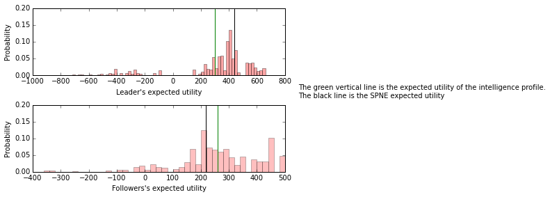

```python
r=TremblingIntelResultsMC(trembling_intels_perfect2, stratprofiles=profs)
r.eu_hist(binwidth=20, power=1)
```

Conclusion : No surprises

### MC sampling for offpath intels

```python
#on_path_intel = no_trembling_intels # Copied from above just for new varname.
p2_info_sets = ["HA", "HB", "HC", "LA", "LB", "LC"]
def get_off_path_info_sets(profile, p2_info_sets = p2_info_sets):
    unvisited = set(p2_info_sets) - set(["H" + profile[0][0]])
    unvisited = unvisited - set(["L" + profile[0][1]])
    return unvisited

def get_off_path_intel_perfect_info(profile, p=.5, numalt=30):
    unvisited = list(get_off_path_info_sets(profile))
    unvisited_intels = []
    for u in unvisited:
        num_no_better = 0.
        nature = u[0]
        p1act = u[1]
        p2s_action = profile[1][(3 * int(nature=="L")) +  mapdict[p1act]]
        utility = utils[nature + p1act + p2s_action][1]
        p2s_other_actions = list(set(["X", "Y", "Z"]) - set(p2s_action))
        for ix in np.random.choice(range(len(p2s_other_actions)), size=numalt):
            other = p2s_other_actions[ix]
            utility_other = utils[u + other][1]
            if utility_other <= utility:
                num_no_better +=1
        unvisited_intels.append(num_no_better/2.)
    return sum(unvisited_intels)/float(len(unvisited_intels))
```

```python
offpath_intels1 = []
onpathintels = []
combined_intels = []
offpathstrats = []
off_path_weight=.1
for ix in np.random.choice(range(len(perfect_stratprofiles)), size=1000):
    s = perfect_stratprofiles[ix]
    offpathintel  = get_off_path_intel_perfect_info(s)
    onpathintel = get_trembling_intelligence_perfect_info_mc(s, p1trembleprob=0, p2trembleprob=0)
    combined_intels.append( (1 - off_path_weight) * onpathintel + off_path_weight * offpathintel)
    offpathstrats.append(s)
```

### Sampling 1000 profiles and 30 alternative profiles - Off-path intel

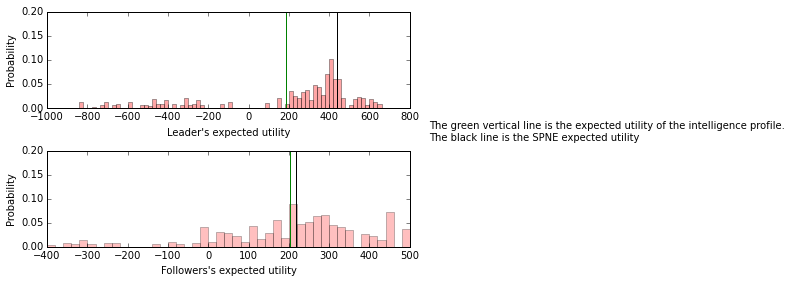

```python
r2=TremblingIntelResultsMC(combined_intels, stratprofiles=offpathstrats)
r2.eu_hist(binwidth=20, power=2)
```

Verdict : No surprises

## Imperfect Information

```python
import itertools
from adsy.display import extended_styles
strat_1 = list(itertools.product(["A", "B", "C"], ["A", "B", "C"]))
strat_2 = list(itertools.product(["X", "Y", "Z"], ["X", "Y", "Z"], ["X", "Y", "Z"]))
```

```python
def EU_imperfect(p1strat, p2strat, utils=utils, p1top2map=mapdict):
    highukey = "H"+p1strat[0]+p2strat[mapdict[p1strat[0]]]
    lowukey =  "L"+p1strat[1]+p2strat[mapdict[p1strat[1]]]
    p1eu = .5 * utils[highukey][0] + .5 * utils[lowukey][0]
    p2eu = .5 * utils[highukey][1] + .5 * utils[lowukey][1]
    return p1eu, p2eu
imperfect_stratprofiles = list(itertools.product(strat_1, strat_2))
```

```python
def get_intelligence_imperfect(profile, numalt=30):
    p1strat = profile[0]
    p2strat = profile[1]
    util = EU_imperfect(p1strat, p2strat)
    #print util
    p1_numalt = float(len(strat_1))
    p2_numalt = float(len(strat_2))
    num_no_betterp1 = 0
    num_no_betterp2 = 0
    for ix in np.random.choice(range(len(strat_1)), size=numalt):
        s = strat_1[ix]
        if EU_imperfect(s, p2strat)[0] <= util[0]:
            num_no_betterp1 +=1
    for ix in np.random.choice(range(len(strat_2)), size=numalt):
        s = strat_2[ix]
        if EU_imperfect(p1strat, s)[1] <= util[1]:
            num_no_betterp2 +=1
    return (num_no_betterp1-1)/(p1_numalt - 1) * (num_no_betterp2 - 1)/(p2_numalt -1)

def get_off_path_info_sets_imperfect(profile):
    unvisited = set(["A", "B", "C"]) - set(list(profile[0]))
    return unvisited

def get_off_path_intel_imperfect(profile, p=.5):
    unvisited = list(get_off_path_info_sets_imperfect(profile))
    unvisited_intels = []
    for u in unvisited:
        num_no_better_high = 0.
        num_no_better_low = 0.
        p2s_action = profile[1][mapdict[u]]
        utility_high = utils["H" + u + p2s_action][1]
        utility_low = utils["L" + u + p2s_action][1]
        p2s_other_actions = list(set(["X", "Y", "Z"]) - set(p2s_action))
        for other in p2s_other_actions:
            utility_high_other = utils["H" + u + other][1]
            utility_low_other = utils["L" + u + other][1]
            if utility_high_other <= utility_high:
                num_no_better_high +=1
            if utility_low_other <= utility_low:
                num_no_better_low +=1
        unvisited_intels.append(p * num_no_better_high/2. + (1-p)* num_no_better_low/2.)


    return sum(unvisited_intels)/float(len(unvisited_intels))
```

```python
class ImperfectResults(object):
    def __init__(self, res, stratprofiles = imperfect_stratprofiles, imperfect_strat_1 = strat_1,
                 imperfect_strat_2=strat_2):
        self.res = np.asarray(res)
        self.stratprofiles = stratprofiles
        self.sorted_ix = np.argsort(self.res)[::-1]
        self.imperfect_strat_1 = imperfect_strat_1
        self.imperfect_strat_2 = imperfect_strat_2

    def make_hist(self):
        plt.hist(self.res)


    def get_perfect_intelligence(self, profile):
        """
        Get's the non-trembling intelligences"""
        p1strat = profile[0]
        p2strat = profile[1]
        util = EU_perfect_info(p1strat, p2strat)
        #print util
        p1_numalt = float(len(self.perfect_strat_1))
        p2_numalt = float(len(self.perfect_strat_2))
        num_no_betterp1 = 0
        num_no_betterp2 = 0
        for s in self.perfect_strat_1:
            if EU_perfect_info(s, p2strat)[0] <= util[0]:
                num_no_betterp1 +=1
        for s in self.perfect_strat_2:
            if EU_perfect_info(p1strat, s)[1] <= util[1]:
                num_no_betterp2 +=1
        return (num_no_betterp1-1)/(p1_numalt - 1) * (num_no_betterp2 - 1)/(p2_numalt -1)


    def EU_imperfect(self, p1strat, p2strat, utils=utils, p1top2map=mapdict):
        highukey = "H"+p1strat[0]+p2strat[mapdict[p1strat[0]]]
        lowukey =  "L"+p1strat[1]+p2strat[mapdict[p1strat[1]]]
        p1eu = .5 * utils[highukey][0] + .5 * utils[lowukey][0]
        p2eu = .5 * utils[highukey][1] + .5 * utils[lowukey][1]
        return p1eu, p2eu

    def eu_dist(self, power = 1, binwidth=10):
        total_prob = np.sum(self.res**power)
        probs = self.res**power/float(total_prob)
        eus = []
        for s in self.stratprofiles:
            eus.append(self.EU_imperfect(s[0], s[1]))
        p1u = defaultdict(int)
        p2u = defaultdict(int)
        for ix, atom in enumerate(eus):
            p1u[int(atom[0]/binwidth) * binwidth ] += probs[ix]
            p2u[int(atom[1]/binwidth) * binwidth ] += probs[ix]
        return p1u, p2u

    def eu_hist(self, power=1, binwidth=10):
        eu_dicts = self.eu_dist(power=power, binwidth=binwidth)
        eu_subgame_perfect = [(625+250)/2. , (312. + 125.)/2.]
        eu_dicts_exact = self.eu_dist(power=power, binwidth=1)
        p1eeu = 0
        p2eeu = 0
        for k, v in eu_dicts_exact[0].iteritems():
            p1eeu += k * v
        for k, v in eu_dicts_exact[1].iteritems():
            p2eeu += k * v
        fig, [ax1, ax2] = plt.subplots(2)
        ax1.bar(eu_dicts[0].keys(), eu_dicts[0].values(), width=binwidth, color='r', alpha=.35)
        ax1.set_xlabel("Leader\'s expected utility")
        ax1.set_ylabel("Probability")
        ax1.vlines(eu_subgame_perfect[0], 0, .2)
        ax1.vlines(p1eeu, 0, .2, color='green')
        ax2.bar(eu_dicts[1].keys(), eu_dicts[1].values(), width=binwidth, color='r', alpha=.25)
        ax2.set_xlabel("Followers\'s expected utility")
        ax2.set_ylabel("Probability")
        ax2.vlines(eu_subgame_perfect[1], 0, .2)
        ax2.vlines(p2eeu, 0, .2, color='green')
        plt.tight_layout()
        fig.text(1, .5, 'The green vertical line is the expected utility of the intelligence profile. \n' + \
                        'The black line is the SPNE expected utility')
        return fig, ax1, ax2

    def eu_cdf(self, power=1):
        p1_dist, p2_dist = self.eu_dist( power = power)
        p1k = p1_dist.keys()
        p1v = p1_dist.values()
        p1_srtd = np.argsort(p1k)
        cumprob_p1 = np.cumsum(np.asarray(p1v)[p1_srtd])
        p2k = p2_dist.keys()
        p2v = p2_dist.values()
        p2_srtd = np.argsort(p2k)
        cumprob_p2 = np.cumsum(np.asarray(p2v)[p2_srtd])
        fig, [ax1, ax2] = plt.subplots(2)
        ax1.plot(np.asarray(p1k)[p1_srtd], cumprob_p1)
        ax1.set_xlabel("CDF of Leader\'s Utility")
        ax2.plot(np.asarray(p2k)[p2_srtd], cumprob_p2)
        ax2.set_xlabel("CDF of Followers\'s Utility")
        plt.tight_layout()
        return fig, ax1, ax2
```

```python
imperfect_infoset_intels = []
off_path_intels = []
profsimp = []
for ix in np.random.choice(range(len(imperfect_stratprofiles)) , size=100):
    p = imperfect_stratprofiles[ix]
    imperfect_infoset_intels.append(get_intelligence_imperfect(p))
    off_path_intels.append(get_off_path_intel_imperfect(p))
    profsimp.append(p)

full_game_intels = np.asarray(off_path_intels) * np.asarray(imperfect_infoset_intels)
```

### Sampling 100 profiles and 30 alternative profiles - Off-path intel

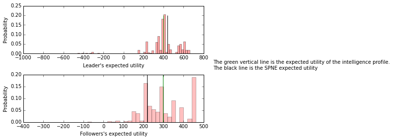

```python
r3=ImperfectResults(full_game_intels, stratprofiles=profsimp)
r3.eu_hist(binwidth=20, power=2)
```

Outcome: No surprises

### Tremblimng Intels

```python
def EU_with_trembles_imperfect(p1strat, p2strat, utils=utils, p1top2map=mapdict, p1trembleprob=.2,
                     p2trembleprob=.2, p1tremblestrats=strat_1, p2tremblestrats=strat_2):
    highukey = "H"+p1strat[0]+p2strat[mapdict[p1strat[0]]]
    lowukey =  "L"+p1strat[1]+p2strat[mapdict[p1strat[1]]]
    p1eunotremb = (1-p2trembleprob) * (.5 * utils[highukey][0] + .5 * utils[lowukey][0])
    p2eunotremb = (1-p1trembleprob) * (.5 * utils[highukey][1] + .5 * utils[lowukey][1])
    ### Get the utility that is associated with p2 trembling
    p1epovern = p1trembleprob/float(len(p1tremblestrats) - 1)
    p2epovern = p2trembleprob/float(len(p2tremblestrats) - 1)
    p1tremblingeu = 0 # Utility of p1 when p2 trembles
    p2tremblingeu = 0 # Utility of p2 when p1 trembles
    for s in p2tremblestrats:
        if s != p2strat:
            highukey = "H"+p1strat[0]+s[mapdict[p1strat[0]]]
            lowukey =  "L"+p1strat[1]+s[mapdict[p1strat[1]]]
            p1tremblingeu += p2epovern * (.5 * utils[highukey][0] + .5 * utils[lowukey][0])
    for s in p1tremblestrats:
        if s != p1strat:
            highukey = "H"+s[0]+p2strat[mapdict[s[0]]]
            lowukey =  "L"+s[1]+p2strat[mapdict[s[1]]]
            p2tremblingeu += p1epovern * (.5 * utils[highukey][1] + .5 * utils[lowukey][1])


    return p1eunotremb + p1tremblingeu, p2eunotremb + p2tremblingeu

def get_trembling_intelligence_perfect(profile, numalt=20): #Deliberately misnamed
    p1strat = profile[0]
    p2strat = profile[1]
    util = EU_with_trembles_imperfect(p1strat, p2strat)
    #print util
    p1_numalt = float(len(strat_1))
    p2_numalt = float(len(strat_2))
    num_no_betterp1 = 0
    num_no_betterp2 = 0
    for ix in np.random.choice(range(len(strat_1)), size=numalt):
        s = strat_1[ix]
        if EU_with_trembles_imperfect(s, p2strat)[0] <= util[0]:
            num_no_betterp1 +=1
    for ix in np.random.choice(range(len(strat_2)), size=numalt):
        s= strat_2[ix]
        if EU_with_trembles_imperfect(p1strat, s)[1] <= util[1]:
            num_no_betterp2 +=1

    return (num_no_betterp1-1)/(p1_numalt - 1) * (num_no_betterp2 - 1)/(p2_numalt -1)
```

```python
lastprofs = []
imper_tremb_intels = []

for ix in np.random.choice(range(len(imperfect_stratprofiles)), size=100):
    p = imperfect_stratprofiles[ix]
    imper_tremb_intels.append(get_trembling_intelligence_perfect(p))
    lastprofs.append(p)
```

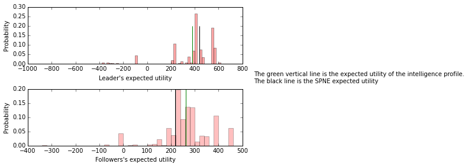

```python
r4=ImperfectResults(imper_tremb_intels, stratprofiles=lastprofs)
r4.eu_hist(binwidth=20, power=2)
```

Result : No surprises

Below should be all self contained so that I can copy and paste to a new notebook

# Justin's Idea

The first two terms captures the idea of intelligence. I am more likely to play strategies that are better against a given profile. The second term is a measure of dominance. That is, strategies that are better against more strategies get more weight in the profile.

Another way to think about it is that we are doing very small intelligence computations for two profiles simultaneously. However, we are not just concerned with the ordering, we are also concerned with the magnitude (i.e. relative change in utilities).

The $\alpha$ parameter controls the responsiveness of the probability to differences in intelligences.

The following properties hold :

1. \begin{equation} \frac{P(s_1, s_2)}{P(s_1', s_2')} = \frac{1}{\frac{P(s_1', s_2')}{P(s_1, s_2)}} \end{equation}
2. Any strategy profile where players are both playing dominant strategies receives the highest probability.
3. All Nash equilibrium profiles do *not* receive the same weight. Instead, the probability the weight they get depends on how they perform against non-equilibrium strategies.

### Perfect Information

```python
import itertools
perfect_strat_1 = list(itertools.product(["A", "B", "C"], ["A", "B", "C"]))
perfect_strat_2 = list(itertools.product(["X", "Y", "Z"], ["X", "Y", "Z"], ["X", "Y", "Z"],
                                         ["X", "Y", "Z"], ["X", "Y", "Z"], ["X", "Y", "Z"]))
perfect_stratprofiles = list(itertools.product(perfect_strat_1, perfect_strat_2))
mapdict = {"A": 0, "B":1, "C":2}
utils = {"HAX": (625, 312),
         "HAY": (1000, 200),
         "HAZ": (900, 252),
         "HBX": (550, 687.5),
         "HBY": (300, 350),
         "HBZ": (660, 462),
         "HCX": (427, 762),
         "HCY": (532, 380),
         "HCZ": (504, 504),
         "LAX": (-2000, -1000),
         "LAY": (-1200, -250),
         "LAZ": (-1500, -420),
         "LBX": (-125, -156),
         "LBY": (250, 125),
         "LBZ": (150, 105),
         "LCX": (17, 31),
         "LCY": (280, 200),
         "LCZ": (210, 210)
}

# for key, val in utils.iteritems():
#     utils[key] = tuple(np.asarray(val)/10000.)
```

```python
def EU_perfect_info(p1strat, p2strat, utils=utils, p1top2map=mapdict):
    """
    Computes the expected utility of player 1 and player 2.

    Nature node is hard coded to p=.5 for both outcomes.

    Setting trembleprobs to 0 gives standard intelligence
    """
    highukey = "H"+p1strat[0]+p2strat[mapdict[p1strat[0]]]
    lowukey =  "L"+p1strat[1]+p2strat[3 + mapdict[p1strat[1]]]
    p1eunotremb = .5 * utils[highukey][0] + .5 * utils[lowukey][0]
    p2eunotremb = .5 * utils[highukey][1] + .5 * utils[lowukey][1]
    return p1eunotremb, p2eunotremb
```

```python
mcmcres = []
mcmcutils =[]
numiters = 1000000
exparam = .001
ixlist = np.arange(0, len(perfect_stratprofiles))
s0 = perfect_stratprofiles[np.random.choice(ixlist)]
for prop in xrange(numiters):
    s1 = perfect_stratprofiles[np.random.choice(ixlist)]
    sc = s1
    sc = perfect_stratprofiles[np.random.choice(ixlist)]
    num =  np.exp(exparam * EU_perfect_info(s1[0], sc[1])[0]) * np.exp(exparam*EU_perfect_info(sc[0], s1[1])[1])
    denom =  np.exp(exparam*EU_perfect_info(s0[0], sc[1])[0]) * np.exp(exparam*EU_perfect_info(sc[0], s0[1])[1])
    unew = EU_perfect_info(s1[0], s1[1])
    #num  = np.prod(unew)
    uold = EU_perfect_info(s0[0], s0[1])
    #denom = np.prod(uold)
    #num*= EU_perfect_info(s1[0],s0[1])[0] * EU_perfect_info(s0[0], s1[1])[1]
    #denom*= EU_perfect_info(s0[0], s1[1])[0] *  EU_perfect_info(s1[0],s0[1])[1]
    arcriteria = (num/denom)
    #arcriteria = 1
    if np.random.random() < arcriteria:
        mcmcres.append(s1)
        s0 = s1
        mcmcutils.append(unew)
    else:
        mcmcres.append(s0)
        mcmcutils.append(uold)
```

```python
mcmcutils = np.asarray(mcmcutils)
eu_subgame_perfect = [(625+250)/2. , (312. + 125.)/2.]
```

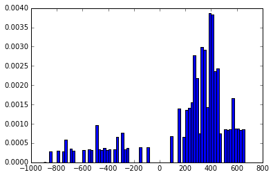

```python
plt.hist(mcmcutils[50000:, 0], normed=True, bins=np.arange(-900,800,20));
```

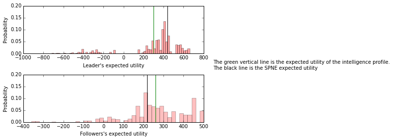

```python
r.eu_hist(binwidth=20)
```

\begin{equation} \frac{P(s_1, s_2)}{P(s_1', s_2')} = \frac{EU_1(s_1, s_2)}{EU_1(s_1', s_2)} \times \frac{EU_2(s_1, s_2)}{EU_2(s_1, s_2')}\times\frac{EU_1(s_1, s_2')}{EU_1(s_1', s_2')} \times \frac{EU_2(s_1', s_2)}{EU_2(s_1', s_2')} \end{equation}